# Quick Start

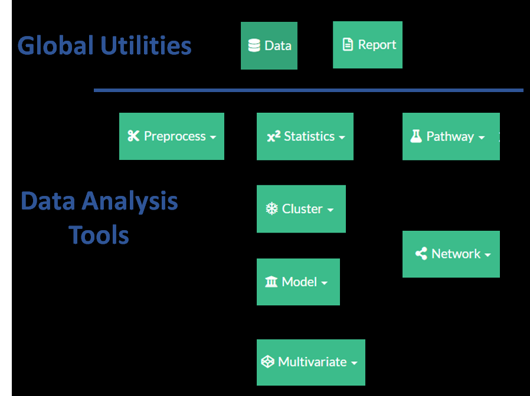

### DAVe is comprised of individual modules which can be linked to create a variety of unique data analysis workflows. The Global Utilities include Data and Report and provide an overview of objects shared by the Data Analysis Tools. The majority of analyses start with data upload using the Data module and then preparation using Preprocess. Check out the Analysis Workflows section for more examles.

[figure not shown]

A

## Select Modules

### The navigation bar is used to select different analyses. Each analysis may also have sub-options. Typical workflows will include choosing modules from the nav bar progressing from left to right and while optimizing each step with sub analyses by progressing through each modules method controls from top to bottom. See the Analysis Workflows section for details how to save and propogate results between induvidual modules.

B

## Module Controls

### The sidebar is used to select analyses methods, tune visualizations and specify report options.

C

## Progress Analyses

### The tabpanel can be used to switch between calculation, interactive exploration, static plotting and report generation. Use calculate to select method options and generate data objects. Explore provides interactive visualizations, while plot is used to tune how the visualizations will appear in the report. The report tab is used to collect all methods, results and plot settings and generate a report of methods and results. The report may also include additional information not present in the previous tabs and can be dynamically populated based on user selected visualizations. All analyses report results can be combined and further manipulated in navbar Report module.

D

## Results and Methods

### This is the main panel where calculation, exploration, plotting and report results will be output to. Results may include both static and interactive results which can be manipulated further.

E

## Help

### Select this icon to to view the help menu for each selected analyses.

# Analysis Workflows

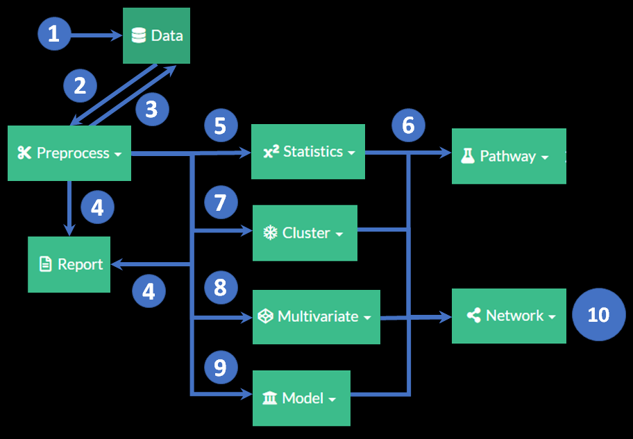

### Each module shares internal workflow elements. The analyses proceed using the calculate tab to set the methods and get results.

[figure not shown]

### The results can be visualized using static plot or interactive explore tabs. The methods, results and created visualizations can be summarized in the report. This can be done iteratively to explore and refine the analysis results and summaries. Once the results reached the data object can be saved using the controls at the bottom of the calculate menu.

1

## Upload Data

### Load data from a `.csv` or saved project.

2

## Prepare Data

[figure not shown]

### Use the Preprocess module to specify sample meta data and merge with variable information. Review and impute missing values.

3

## Save Results

### Each modules calculations and results can be saved and used in further analyses. The save controls found at the bottom of each module's controls menu can be used to specify various parameters to add to the global data sets.

4

## Generate Reports

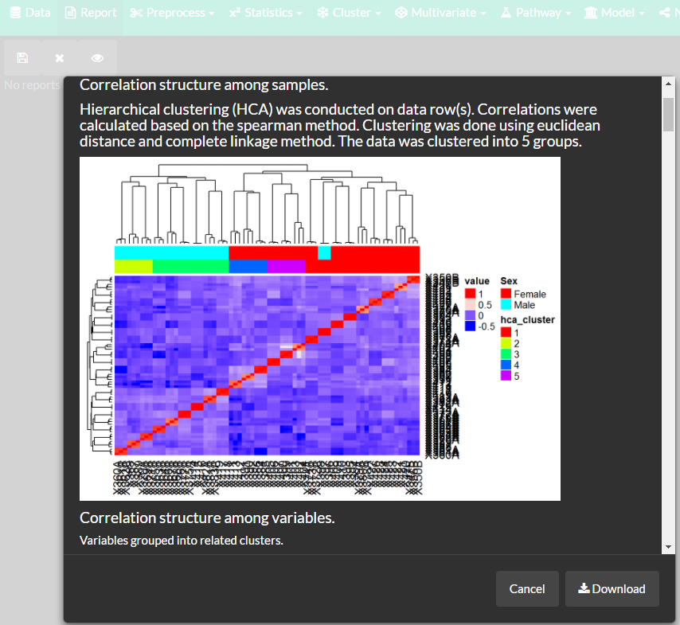

### Each modules results, methods and visualizations can be saved to the analysis report. Individual module's reports can be combined and further modified using the global report module.

5

## Statistical Analysis

[figure not shown]

### The statistics module can be used to compare changes in variables among groups of samples and calculate summary statistics.

6

## Pathway Analysis

[figure not shown]

### The p-values and fold changes calculated statistics module can be used to calculate pathway enrichment. The enriched pathways can be visualized to show the direction of significant changes in variables mapped to biochemical pathways.

7

## Clustering

[figure not shown]

### Use the cluster module to identify groups of related samples or variables. Use Hierarchical Clustering (HCA) on the full data or sample and variable correlation. Visualize meta data and cluster relationships with heatmaps and dendrograms.

8

## Dimensional Reduction

[figure not shown]

### Use the multivariate module to calculate lower dimensional summaries of multivariate data. Use Principal Components Analysis (PCA) to visualize the major modes of variance in samples, variables and their correlations.

9

## Predictive Modeling

[figure not shown]

### Use the model module to calculate machine learning (ML) models to identify predictive relationships for groups or continuous variables. Use auto ML to optimize and tune models while choosing from over 200 available algorithms. Carry out feature selection to rank important variables for explaining the model performance.

10

## Network Analysis and Mapping

[figure not shown]

### Use the network module to identify biochemical, structural similarity and regularized correlation relationships between variables.

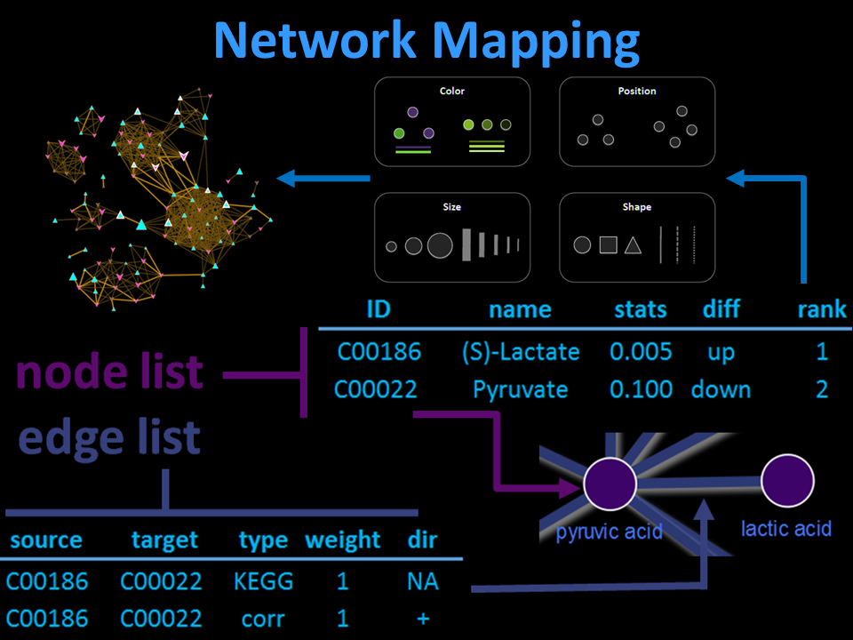

### Use the network module to combine the results from other modules by using network mapping to visualize meta data, statistical, clustering, dimensional reduction, predictive modeling and pathway analysis results. Use highly interactive network visualizations to fine tune publication quality static graphics.